# Case Study Two

## Diabetes Readmission Study

#### David Grijalva, Nicole Norelli, & Mingyang Nick YU

#### 9/17/2021

**Abstract**

The following deliverable investigated and predicted diabetes patients for hospital readmission. Different aspects of each patient's visit were collected and logistic regression with regularization was the primary machine learning method used. Due to the nature of the area, missing data and ethical concerns were addressed. Cross validation was utilized for model selection and model evaluation between different tuning parameters. Feature importance, highlighting the most important features contributing to each target category, as well as results and benefits of the prediction model were later discussed.

## 1. Introduction

This case study focused on predicting whether an admitted diabetes patient would be readmitted based on the characteristics of each patient and hospital outcomes. Information was extracted based on several criteria, including whether it was a diabetic encounter, if the stay at the hospital was between 1-14 days, if lab tests were performed, if medications were administered, etc. Details can be found [here](https://archive.ics.uci.edu/ml/datasets/diabetes+130-us+hospitals+for+years+1999-2008#).

#### Logistic Regression

Logistic Regression was utilized to perform the classification task for this case study. It uses the sigmoid function to convert the target variable between zero and one. Similar to Multiple Linear Regression, Logistic Regression can utilize both categorical variables and numeric variables as predictors. Another benefit of using Logistic Regression is the interpretation of variable importance. When predictors are transformed to the same range, the coefficient of each variable can be used to determine how much it is contributing to predicting the relevant outcome.

For binary classification problems, Logistic Regression takes a two-part loss function. When the target $y$ is 1 loss is: $-y\log(p)$, when the target is 0 loss is: $ (1-y) \log(1-p)$. Multi-class classification problems can be broken down into binary classification problems, using a strategy such as One vs. Rest. For each class, the modle is trained on a true/false basis against the rest of the classes. The Scikit-learn package used for this study supports this option. One potential downfall for this method is that it can suffer from unbalanced negative examples when the class being compared has few observations.

Another Logistic regression model for a multi-class classification problem supplied by Scikit-learn is multinomial solver. It uses the idea of maximum likelihood. Conditional likelihood of $G$ given $X$. Since $Pr(G|X)$ completely specifies the conditional distribution, the multinomial distribution is appropriate. Below is the formula for the log-likelihood for $N$ observations (see details in [textbook](http://web.stanford.edu/~hastie/ElemStatLearn/) section 4.4.1):

$l({\Theta}) = \sum_{i=1}^{N} \log(p_{g_{i}}) * (x_{i};\Theta)$

where $p_{k}(x_{i};\Theta) = Pr(G = k|X= x_{i};\Theta)$.

#### Ridge Regularization (L2)

Ridge regularization, or L2, is utilized as a penalty term for Logistic Regression in Scikit-learn by default. The penalty for this is the squared coefficients multiplied by Lambda, which controls the strength of the penalty. Unlike L1 regularization, L2 does not provide feature selection. All features are penalized uniformly but will never reach to zero. In general, L2 is the primary regularization method used to prevent overfitting the model.

**Penalty Term**  
$\lambda \sum\limits_{j=0}^k m_j ^2 $  
Where $\lambda $ is the strength of the penalty. If $\lambda=0 $ then there would be no penalty applied and the original coefficient would be returned.

#### Target Class Imbalance

Target class imbalance was a potential concern for this study with class "NO" being the majority class (around 54% of all encounters). In order to give each minority class a fair chance to be evaluated during the grid search for best performing parameters, scoring="roc_auc_ovr_weighted" (area under the curve using one-vs-rest comparison with average metrics of each label weighted by support) was utilized. The goal was to predict target classes "<30", ">30" and "NO" equally well, instead of only achieving a higher accuracy score by predicting everything to the "NO" majority class.

## 2. Methods

#### Initial Data Observations

This dataset contained 49 features for 101,766 patient encounters. The feature "encounter_id" was unique to each encounter, and the feature "patient_nbr" identified each of the 71,518 unique patients. Of the patients, 54,745 had only one encounter, while the remaining patients had multiple encounters. Repeat encounters from the same individual violate the independence assumption associated with logistic regression; however the information available in these repeat encounters was valuable. An initial exploration of repeat encounters showed the same individuals receiving different types of diagnoses, medications, and tests from different specialties with different outcomes. Although it potentially biases the results of the study, the data from these repeat patients was retained.

The features "encounter_id" and "patient_nbr" were specific to encounters and patients, so they were deleted from the dataset prior to analysis.

#### Consolidation of Categories

Four of the features (medical_specialty, diag_1, diag_2, and diag_3) had a large number of categories. The medical_specialty feature contained many categories with only a few values. The 15 specialties with the largest number of values were selected to remain, and all other (non-missing) categories were consolidated into a category "Others."

The "diag_1", "diag_2", and "diag_3" features had 717, 749, and 790 categories, respectively. Values in each of these diagnoses categories are International Classification of Diseases (ICD-9) codes. These codes can be grouped into general categories ([example found here](https://en.wikipedia.org/wiki/List_of_ICD-9_codes)), and inspiration for this technique was taken from Strack et al. ([article](https://www.hindawi.com/journals/bmri/2014/781670/tab2/)). For each of the three diagnoses features, values were consolidated into 19 categories plus one category for missing values. A diagnosis of diabetes mellitus was the only specific diagnosis to keep its own category, as it was the focus of the study.

#### Missing Data

Seven features contained missing values (Table 1). Because the feature "weight" was missing more than 96% of its values, imputation was not attempted and it was deleted from the dataset prior to analysis. For the remaining six features with missing data, two different imputation strategies were attempted, and the results were compared after fitting the logistic regression model.

The first imputation strategy involved replacing the missing values in each of the six features with a flag value ("NA") to mark values as missing.

The second imputation strategy used Scikit-learn's SimpleImputer to replace each of the missing values with the most frequent value in each feature, as only categorical data was missing.

**Missing Data**

| Feature | Percentage Missing |
| --- | --- |
| race | 2.2336% |
| weight | 96.8585% |
| payer_code | 39.5574% |
| medical_specialty | 49.0822% |
| diag_1 | 0.0206% |
| diag_2 | 0.3518% |
| diag_3 | 1.3983% |

Table 1: Percentage of missing data for each variable

#### Creating Models Using Pipeline

Each model was created using a pipeline. A pipeline allowed for the streamlining of scaling using MinMaxScaler(), one hot encoding using OneHotEncoder(), and tuning the hyperparameters of the logistic regression model. Additionally, SimpleImputer() was incorporated into one pipeline to implement and compare the different imputation methods. Pipelines prevent data leakage when using grid search with 10-fold cross validation in order to narrow down the best regularization parameter. Because the outcome classes were imbalanced, a stratified cross validation was used and the logistic regression parameter for class weight was set to 'balanced'. A random state was also set for reproducibility.

#### Alternative Model

Concerns over the use of a "race" feature resulted in the creation of an alternative model. Race was deleted from the dataset and the remaining flag values were used for imputation. The pipeline from Model 1 was implemented. The best combination (highest value for area under the curve using one-vs-rest comparison with average metrics of each label weighted by support) was C = 30 using 'ovr.'

## 3. Results

#### Models

[output not shown]

Table 2: Weighted AUC per model

The confusion matrices for Model 1 (Fig. 1) and Model 2 (Fig. 2) demonstrate the prediction details of each model when making predictions on the entire dataset. Precision and recall for each class label can be calculated through the matrix if needed. For example, under Model 1: Precision for "Not Readmitted" class can be calculated by:

$ Precision = 40829\div(40829+17530+5045) = 0.64 $

Recall for "Not Readmitted" class can be calculated by:

$ Recall = 40829\div(40829+11149+2886) = 0.74 $

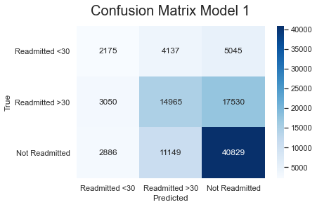

```python
cm_n = confusion_matrix(y, y_hat_lg)
ax = sns.heatmap(cm_n,cmap='Blues',annot=True,fmt='2d',xticklabels=x_axis_labels, yticklabels=y_axis_labels)
ax.set(xlabel='Predicted', ylabel='True')
ax.set_title("Confusion Matrix Model 1",fontdict={'fontsize':20},pad=15)
```

Figure 1: Confusion matrix for Model 1 (flag value imputation)

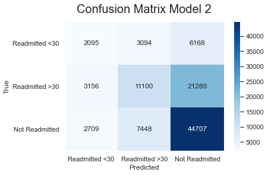

```python
cm_n = confusion_matrix(y, y_hat_lg_method_2)
ax = sns.heatmap(cm_n,cmap='Blues',annot=True,fmt='2d',xticklabels=x_axis_labels, yticklabels=y_axis_labels)
ax.set(xlabel='Predicted', ylabel='True')
ax.set_title("Confusion Matrix Model 2",fontdict={'fontsize':20},pad=15)
```

Figure 2: Confusion matrix for Model 2 (mode imputation)

#### Feature Importance

There was a great deal of overlap between the feature importance contributing to each target outcome in the two models. For the "<30" days readmission target, both Model 1 (Fig. 3) and Model 2 (Fig. 4) had the same top 10 features with slight differences in coefficients, hinting that the imputation method did not significantly change what the model considered important features. For the ">30" days readmission target, both Model 1 (Fig. 5) and Model 2 (Fig. 6) had the same top five features. For the remaining five features, there were some slight differences in order. For example, in Model 1 glyburide_meltformin_Down was at position number 10, while in Model 2 this feature was at position 8. For the "No Readmission" target, the top 8 features are the same in Model 1 (Fig. 7) and Model 2 (Fig. 8) with some slight differences in coefficients.

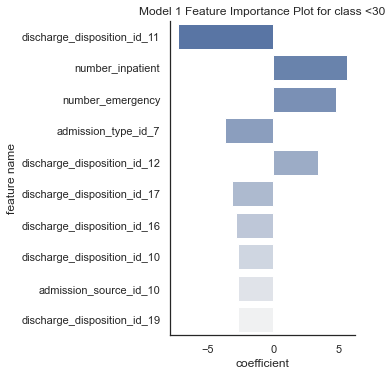

```python
sns.catplot(x="coefficient",
            y="feature name",
            kind="bar",
            palette = "light:b_r",
            data=less_30.sort_values(by='coefficient', key=abs,ascending=False)[:10]).set(title="Model 1 Feature Importance Plot for class <30")
```

Figure 3: Top ten most important features for Model 1 readmission under 30 days outcome

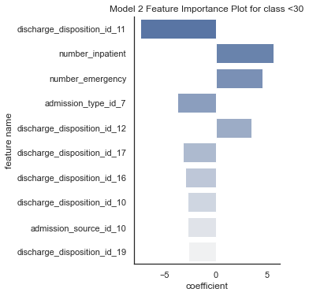

```python
sns.catplot(x="coefficient",
            y="feature name",
            kind="bar",
            palette = "light:b_r",
            data=less_30_impute.sort_values(by='coefficient', key=abs,ascending=False)[:10]).set(title="Model 2 Feature Importance Plot for class <30")

None
```

Figure 4: Top ten most important features for Model 2 readmission under 30 days outcome

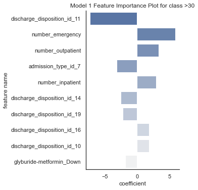

```python
sns.catplot(x="coefficient",
            y="feature name",
            kind="bar",
            palette = "light:b_r",
            data=greater_30.sort_values(by='coefficient', key=abs,ascending=False)[:10]).set(title="Model 1 Feature Importance Plot for class >30")
```

Figure 5: Top ten most important features for Model 1 readmission over 30 days outcome

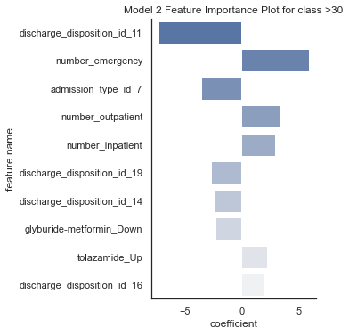

```python
sns.catplot(x="coefficient",
            y="feature name",
            kind="bar",
            palette = "light:b_r",
            data=greater_30_impute.sort_values(by='coefficient', key=abs,ascending=False)[:10]).set(title="Model 2 Feature Importance Plot for class >30")

None
```

Figure 6: Top ten most important features for Model 2 readmission over 30 days outcome

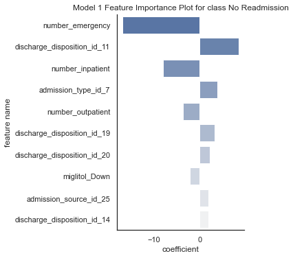

```python
sns.catplot(x="coefficient",
            y="feature name",
            kind="bar",
            palette = "light:b_r",
            data=no_admission.sort_values(by='coefficient', key=abs,ascending=False)[:10]).set(title="Model 1 Feature Importance Plot for class No Readmission")
```

Figure 7: Top ten most important features for Model 1 no readmission outcome

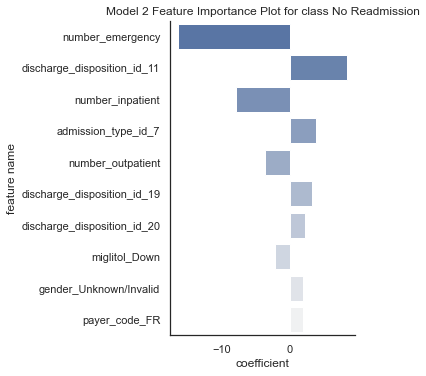

```python
sns.catplot(x="coefficient",
            y="feature name",
            kind="bar",
            palette = "light:b_r",
            data=no_admission_impute.sort_values(by='coefficient', key=abs,ascending=False)[:10]).set(title="Model 2 Feature Importance Plot for class No Readmission")

None
```

Figure 8: Top ten most important features for Model 2 no readmission outcome

| Model 1 | Model 2 |
| --- | --- |
| discharge_disposition_id_11 | discharge_disposition_id_11 |
| number_inpatient | number_inpatient |
| number_emergency | number_emergency |
| admission_type_id_7 | admission_type_id_7 |
| discharge_disposition_id_12 | discharge_disposition_id_12 |

| Model 1 | Model 2 |
| --- | --- |
| number_emergency | number_emergency |
| discharge_disposition_id_11 | discharge_disposition_id_11 |
| number_inpatient | number_inpatient |
| admission_type_id_7 | admission_type_id_7 |
| number_outpatient | number_outpatient |

Table 4: Top 5 features per model for No Readmission target

#### Alternative Model

To explore the necessity of retaining a feature for race, an alternative model was based on Model 1, the best-performing model. The only difference between them was the deletion of the "race" feature for the alternative model. Results were very similar to that of Model 1, with a weighted AUC of 0.67904 for the alternative model and 0.67998 for Model 1.

This study chose to retain the race feature, as the subject matter was medical and different demographics can be affected by medical issues differently. Also, retaining the race feature allowed for the possibility that patients of different races could have been given different qualities of medical care. An examination of feature importance in Models 1 and 2 showed that race was not one of the more important features. The very small effect its removal had on model results also supports this. While it may still contribute a small amount of useful information for prediction, a race feature does not appear to be essential. While the recommended model (Model 1) retains it, the alternative model is a viable option if there are ethical concerns about the implementation and use of the model.

## 4. Conclusion

Model 1 was the best model for predicting the hospital readmission of diabetes patients. Both models had very similar performance. This might hint that for this problem or data, the imputation method contributed very little to a higher AUC score. For this study, no feature selection was used, meaning both models used the same number of variables.

Regarding the imputation method used, as seen by the AUC scores, there was very little advantage between using either method. Something to note is that generally speaking, the imputation used in model 2 is less prone to data leakage, meaning that some information from the training data leaks into the test data. The reason for this is that when using the GridSearch objective in each cross validation split, the data is being divided into different train and test groups. The imputation values are calculated from the training group, and those same values are then applied to the test group. So no information from the data points on the test group is used to calculate the imputation values. Future improvements to increase the accuracy of this classification problem could include attempting to do some feature selection or trying different algorithms such as xgboost, which can handle missing data without imputation.

## Appendix - Code

```python
import pandas as pd
import numpy as np
import matplotlib.pyplot as plt
import seaborn as sns

from sklearn.preprocessing import label_binarize
from scipy import interp
from itertools import cycle
import warnings
warnings.filterwarnings("ignore")


from sklearn.preprocessing import OneHotEncoder, MinMaxScaler
from sklearn.pipeline import Pipeline
from sklearn.compose import ColumnTransformer
from sklearn.model_selection import train_test_split,GridSearchCV,StratifiedKFold
from sklearn.linear_model import LogisticRegression
from sklearn.metrics import classification_report,plot_confusion_matrix,plot_roc_curve, auc, roc_curve,confusion_matrix

import joblib
sns.set_theme()
# options
pd.set_option('display.max_columns', None)
# Using fixed os structure
import os
cwd = os.getcwd()
d = os.path.dirname(cwd)
d

# Notebook options
pd.options.display.max_rows = 99999
pd.options.display.max_columns = 99999
#pd.options.display.float_format = '{:20,.3f}'.format
```

### Initial Data Read In and Conversion

```python
path_file = f"{d}/casestudy2/dataset_diabetes/diabetic_data.csv"
raw_data = pd.read_csv(path_file)
# Convert columns to correct type
raw_data["encounter_id"] = raw_data["encounter_id"].astype(str)
raw_data["patient_nbr"] = raw_data["patient_nbr"].astype(str)
raw_data["admission_type_id"] = raw_data["admission_type_id"].astype(str)
raw_data["discharge_disposition_id"] = raw_data["discharge_disposition_id"].astype(str)
raw_data["admission_source_id"] = raw_data["admission_source_id"].astype(str)
```

### Exploratory Data Analysis

```python
raw_data.shape
```

```
(101766, 50)
```

```python
raw_data.info()
```

```
<class 'pandas.core.frame.DataFrame'>
RangeIndex: 101766 entries, 0 to 101765
Data columns (total 50 columns):
 #   Column                    Non-Null Count   Dtype
---  ------                    --------------   -----
 0   encounter_id              101766 non-null  object
 1   patient_nbr               101766 non-null  object
 2   race                      101766 non-null  object
 3   gender                    101766 non-null  object
 4   age                       101766 non-null  object
 5   weight                    101766 non-null  object
 6   admission_type_id         101766 non-null  object
 7   discharge_disposition_id  101766 non-null  object
 8   admission_source_id       101766 non-null  object
 9   time_in_hospital          101766 non-null  int64
```

[output cut: 42 more lines]

```python
# Identify attributes missing over 15% of values
columns_missing_rate = 100*((raw_data=="?").sum(axis = 0) / len(raw_data))
columns_missing_rate = pd.DataFrame(columns_missing_rate)
columns_missing_rate = columns_missing_rate.reset_index()
columns_missing_rate.columns = ['name','rate']
print("     Initial Missing Data Inspection with all Attributes In     \n")
print('{:45s} {:4s}%'.format("Variable Name:","Missing Percentage"))
print("________________________________________________________________")
for index, row in columns_missing_rate.iterrows():
    if row['rate'] > 0:
        print(' {:45s} {:4s}%'.format(row['name'],str(np.round(row['rate'],4))))
```

```
     Initial Missing Data Inspection with all Attributes In

Variable Name:                                Missing Percentage%
________________________________________________________________
 race                                          2.2336%
 weight                                        96.8585%
 payer_code                                    39.5574%
 medical_specialty                             49.0822%
 diag_1                                        0.0206%
 diag_2                                        0.3518%
 diag_3                                        1.3983%
```

```python
raw_data.head(20)
```

|  | encounter_id | patient_nbr | race | gender | age | weight | admission_type_id | discharge_disposition_id | admission_source_id | time_in_hospital | payer_code | medical_specialty | num_lab_procedures | num_procedures | num_medications | number_outpatient | number_emergency | number_inpatient | diag_1 | diag_2 | diag_3 | number_diagnoses | max_glu_serum | A1Cresult | metformin | repaglinide | nateglinide | chlorpropamide | glimepiride | … |
| --- | --- | --- | --- | --- | --- | --- | --- | --- | --- | --- | --- | --- | --- | --- | --- | --- | --- | --- | --- | --- | --- | --- | --- | --- | --- | --- | --- | --- | --- | --- |
| 0 | 2278392 | 8222157 | Caucasian | Female | [0-10) | ? | 6 | 25 | 1 | 1 | ? | Pediatrics-Endocrinology | 41 | 0 | 1 | 0 | 0 | 0 | 250.83 | ? | ? | 1 | None | None | No | No | No | No | No | … |
| 1 | 149190 | 55629189 | Caucasian | Female | [10-20) | ? | 1 | 1 | 7 | 3 | ? | ? | 59 | 0 | 18 | 0 | 0 | 0 | 276 | 250.01 | 255 | 9 | None | None | No | No | No | No | No | … |
| 2 | 64410 | 86047875 | AfricanAmerican | Female | [20-30) | ? | 1 | 1 | 7 | 2 | ? | ? | 11 | 5 | 13 | 2 | 0 | 1 | 648 | 250 | V27 | 6 | None | None | No | No | No | No | No | … |
| 3 | 500364 | 82442376 | Caucasian | Male | [30-40) | ? | 1 | 1 | 7 | 2 | ? | ? | 44 | 1 | 16 | 0 | 0 | 0 | 8 | 250.43 | 403 | 7 | None | None | No | No | No | No | No | … |
| 4 | 16680 | 42519267 | Caucasian | Male | [40-50) | ? | 1 | 1 | 7 | 1 | ? | ? | 51 | 0 | 8 | 0 | 0 | 0 | 197 | 157 | 250 | 5 | None | None | No | No | No | No | No | … |
| 5 | 35754 | 82637451 | Caucasian | Male | [50-60) | ? | 2 | 1 | 2 | 3 | ? | ? | 31 | 6 | 16 | 0 | 0 | 0 | 414 | 411 | 250 | 9 | None | None | No | No | No | No | No | … |
| 6 | 55842 | 84259809 | Caucasian | Male | [60-70) | ? | 3 | 1 | 2 | 4 | ? | ? | 70 | 1 | 21 | 0 | 0 | 0 | 414 | 411 | V45 | 7 | None | None | Steady | No | No | No | Steady | … |
| 7 | 63768 | 114882984 | Caucasian | Male | [70-80) | ? | 1 | 1 | 7 | 5 | ? | ? | 73 | 0 | 12 | 0 | 0 | 0 | 428 | 492 | 250 | 8 | None | None | No | No | No | No | No | … |
| 8 | 12522 | 48330783 | Caucasian | Female | [80-90) | ? | 2 | 1 | 4 | 13 | ? | ? | 68 | 2 | 28 | 0 | 0 | 0 | 398 | 427 | 38 | 8 | None | None | No | No | No | No | No | … |
| 9 | 15738 | 63555939 | Caucasian | Female | [90-100) | ? | 3 | 3 | 4 | 12 | ? | InternalMedicine | 33 | 3 | 18 | 0 | 0 | 0 | 434 | 198 | 486 | 8 | None | None | No | No | No | No | No | … |
| 10 | 28236 | 89869032 | AfricanAmerican | Female | [40-50) | ? | 1 | 1 | 7 | 9 | ? | ? | 47 | 2 | 17 | 0 | 0 | 0 | 250.7 | 403 | 996 | 9 | None | None | No | No | No | No | No | … |
| 11 | 36900 | 77391171 | AfricanAmerican | Male | [60-70) | ? | 2 | 1 | 4 | 7 | ? | ? | 62 | 0 | 11 | 0 | 0 | 0 | 157 | 288 | 197 | 7 | None | None | No | No | No | No | No | … |
| 12 | 40926 | 85504905 | Caucasian | Female | [40-50) | ? | 1 | 3 | 7 | 7 | ? | Family/GeneralPractice | 60 | 0 | 15 | 0 | 1 | 0 | 428 | 250.43 | 250.6 | 8 | None | None | Steady | Up | No | No | No | … |
| 13 | 42570 | 77586282 | Caucasian | Male | [80-90) | ? | 1 | 6 | 7 | 10 | ? | Family/GeneralPractice | 55 | 1 | 31 | 0 | 0 | 0 | 428 | 411 | 427 | 8 | None | None | No | No | No | No | No | … |
| 14 | 62256 | 49726791 | AfricanAmerican | Female | [60-70) | ? | 3 | 1 | 2 | 1 | ? | ? | 49 | 5 | 2 | 0 | 0 | 0 | 518 | 998 | 627 | 8 | None | None | No | No | No | No | No | … |
| 15 | 73578 | 86328819 | AfricanAmerican | Male | [60-70) | ? | 1 | 3 | 7 | 12 | ? | ? | 75 | 5 | 13 | 0 | 0 | 0 | 999 | 507 | 996 | 9 | None | None | No | No | No | No | No | … |
| 16 | 77076 | 92519352 | AfricanAmerican | Male | [50-60) | ? | 1 | 1 | 7 | 4 | ? | ? | 45 | 4 | 17 | 0 | 0 | 0 | 410 | 411 | 414 | 8 | None | None | No | No | No | No | No | … |
| 17 | 84222 | 108662661 | Caucasian | Female | [50-60) | ? | 1 | 1 | 7 | 3 | ? | Cardiology | 29 | 0 | 11 | 0 | 0 | 0 | 682 | 174 | 250 | 3 | None | None | No | No | No | No | No | … |
| 18 | 89682 | 107389323 | AfricanAmerican | Male | [70-80) | ? | 1 | 1 | 7 | 5 | ? | ? | 35 | 5 | 23 | 0 | 0 | 0 | 402 | 425 | 416 | 9 | None | None | No | No | No | No | No | … |
| 19 | 148530 | 69422211 | ? | Male | [70-80) | ? | 3 | 6 | 2 | 6 | ? | ? | 42 | 2 | 23 | 0 | 0 | 0 | 737 | 427 | 714 | 8 | None | None | No | No | No | No | No | … |

#### Numerical Data

```python
# Look at numerical data - except encounter_id and patient_nbr
raw_data[raw_data.select_dtypes(include="number").columns].describe()
```

|  | time_in_hospital | num_lab_procedures | num_procedures | num_medications | number_outpatient | number_emergency | number_inpatient | number_diagnoses |
| --- | --- | --- | --- | --- | --- | --- | --- | --- |
| count | 101766.000000 | 101766.000000 | 101766.000000 | 101766.000000 | 101766.000000 | 101766.000000 | 101766.000000 | 101766.000000 |
| mean | 4.395987 | 43.095641 | 1.339730 | 16.021844 | 0.369357 | 0.197836 | 0.635566 | 7.422607 |
| std | 2.985108 | 19.674362 | 1.705807 | 8.127566 | 1.267265 | 0.930472 | 1.262863 | 1.933600 |
| min | 1.000000 | 1.000000 | 0.000000 | 1.000000 | 0.000000 | 0.000000 | 0.000000 | 1.000000 |
| 25% | 2.000000 | 31.000000 | 0.000000 | 10.000000 | 0.000000 | 0.000000 | 0.000000 | 6.000000 |
| 50% | 4.000000 | 44.000000 | 1.000000 | 15.000000 | 0.000000 | 0.000000 | 0.000000 | 8.000000 |
| 75% | 6.000000 | 57.000000 | 2.000000 | 20.000000 | 0.000000 | 0.000000 | 1.000000 | 9.000000 |
| max | 14.000000 | 132.000000 | 6.000000 | 81.000000 | 42.000000 | 76.000000 | 21.000000 | 16.000000 |

```python
corr = raw_data[raw_data.select_dtypes(include="number").columns].corr().abs()
```

```python
upper_tri = corr.where(np.triu(np.ones(corr.shape),k=0).astype(np.bool))
```

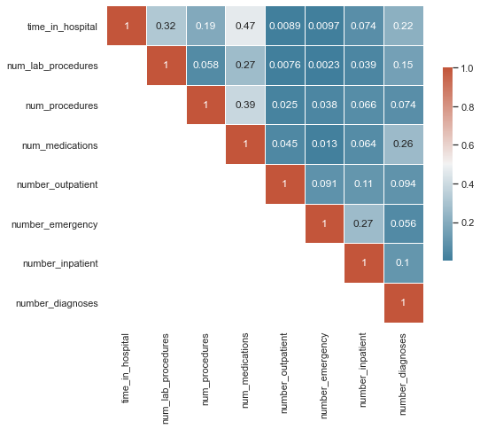

```python
sns.set_theme(style="white")
plt.subplots(figsize=(8,8))
cmap = sns.diverging_palette(230, 20, as_cmap=True)
sns.heatmap(upper_tri, cmap=cmap, vmax=1, center=0.5,annot=True,
            square=True, linewidths=.5, cbar_kws={"shrink": .5})
```

```python
numeric_columns = raw_data[raw_data.select_dtypes(include="number").columns].sample(frac=0.2,random_state=101)
```

```python
numeric_columns = pd.concat([numeric_columns,raw_data['readmitted'].sample(frac=0.2,random_state=101)],axis=1)
```

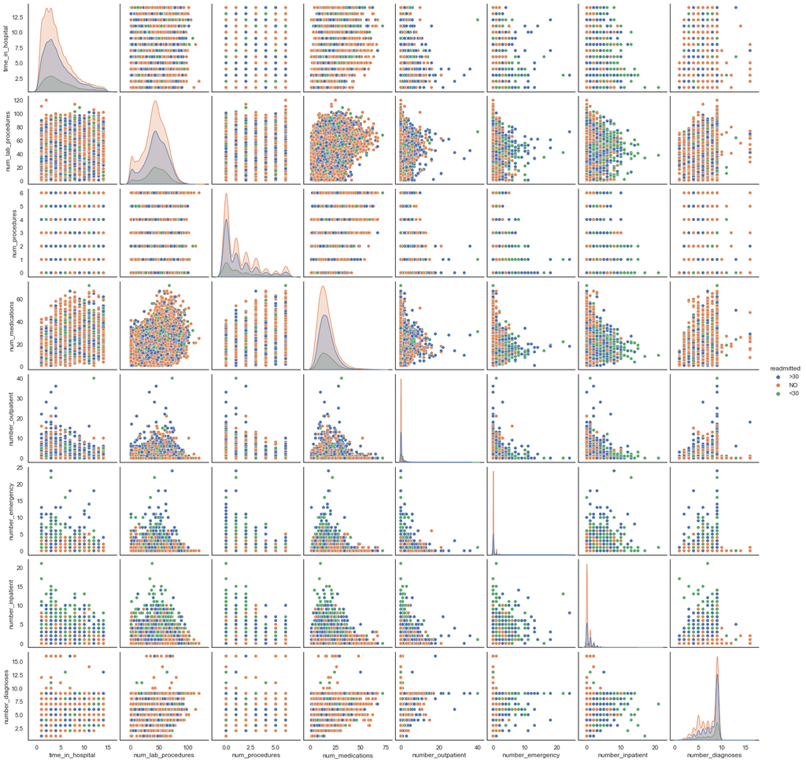

```python
sns.pairplot(numeric_columns,hue='readmitted')
```

```python
raw_data.loc[raw_data['readmitted']=='<30',['time_in_hospital','readmitted']].head()
```

|  | time_in_hospital | readmitted |
| --- | --- | --- |
| 11 | 7 | <30 |
| 12 | 7 | <30 |
| 16 | 4 | <30 |
| 46 | 9 | <30 |
| 50 | 4 | <30 |

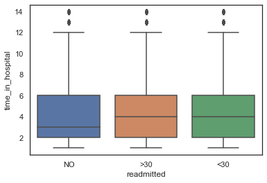

```python
sns.boxplot(data=raw_data[['time_in_hospital','readmitted']], x="readmitted",y="time_in_hospital")
```

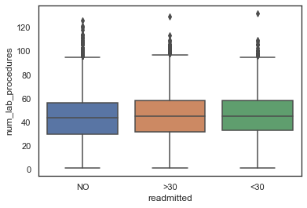

```python
sns.boxplot(data=raw_data.loc[raw_data['num_lab_procedures']>-1,['num_lab_procedures','readmitted']], x="readmitted",y="num_lab_procedures")
```

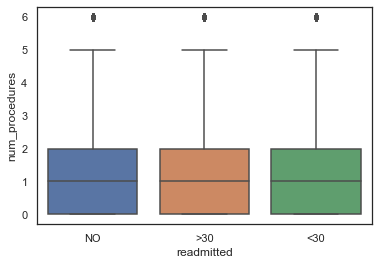

```python
sns.boxplot(data=raw_data.loc[raw_data['num_procedures']>-1,['num_procedures','readmitted']], x="readmitted",y="num_procedures")
```

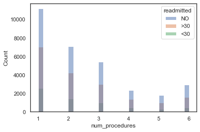

```python
# Displaying only rows with number_outpatient > 0
sns.histplot(raw_data.loc[raw_data['num_procedures']>0,['num_procedures','readmitted']],x = 'num_procedures',hue='readmitted',bins = 30)
```

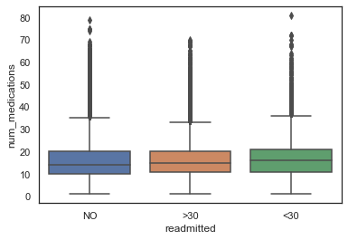

```python
sns.boxplot(data=raw_data.loc[raw_data['num_medications']>-1,['num_medications','readmitted']], x="readmitted",y="num_medications")
```

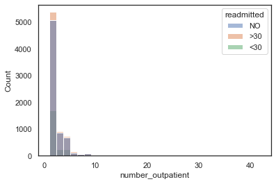

```python
# Displaying only rows with number_outpatient > 0
sns.histplot(raw_data.loc[raw_data['number_outpatient']>0,['number_outpatient','readmitted']],x = 'number_outpatient',hue='readmitted',bins = 30)
```

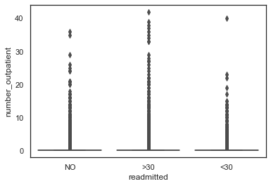

```python
sns.boxplot(data=raw_data.loc[raw_data['number_outpatient']>-1,['number_outpatient','readmitted']], x="readmitted",y="number_outpatient")
```

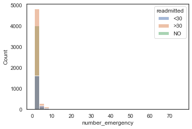

```python
# Displaying only rows with number_emergency > 0
sns.histplot(raw_data.loc[raw_data['number_emergency']>0,['number_emergency','readmitted']],x = 'number_emergency',hue='readmitted',bins = 30)
```

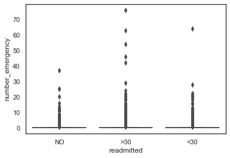

```python
sns.boxplot(data=raw_data.loc[raw_data['number_emergency']>-1,['number_emergency','readmitted']], x="readmitted",y="number_emergency")
```

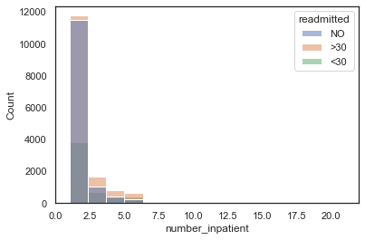

```python
# Displaying number_inpatient > 0
sns.histplot(raw_data.loc[raw_data['number_inpatient']>0,['number_inpatient','readmitted']],x = 'number_inpatient',hue='readmitted',bins = 15)
```

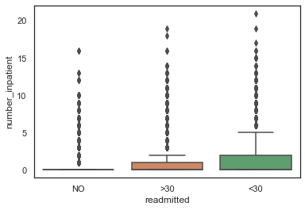

```python
sns.boxplot(data=raw_data.loc[raw_data['number_inpatient']>-1,['number_inpatient','readmitted']], x="readmitted",y="number_inpatient")
```

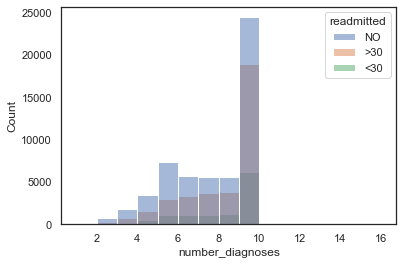

```python
sns.histplot(raw_data[['number_diagnoses','readmitted']],x = 'number_diagnoses',hue='readmitted',bins = 15)
```

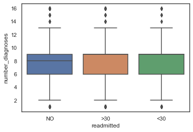

```python
sns.boxplot(data=raw_data.loc[raw_data['number_diagnoses']>-1,['number_diagnoses','readmitted']], x="readmitted",y="number_diagnoses")
```

#### Categorical Data

```python
raw_data[raw_data.select_dtypes(exclude="number").columns].describe()
```

|  | encounter_id | patient_nbr | race | gender | age | weight | admission_type_id | discharge_disposition_id | admission_source_id | payer_code | medical_specialty | diag_1 | diag_2 | diag_3 | max_glu_serum | A1Cresult | metformin | repaglinide | nateglinide | chlorpropamide | glimepiride | acetohexamide | glipizide | glyburide | tolbutamide | pioglitazone | rosiglitazone | acarbose | miglitol | … |
| --- | --- | --- | --- | --- | --- | --- | --- | --- | --- | --- | --- | --- | --- | --- | --- | --- | --- | --- | --- | --- | --- | --- | --- | --- | --- | --- | --- | --- | --- | --- |
| count | 101766 | 101766 | 101766 | 101766 | 101766 | 101766 | 101766 | 101766 | 101766 | 101766 | 101766 | 101766 | 101766 | 101766 | 101766 | 101766 | 101766 | 101766 | 101766 | 101766 | 101766 | 101766 | 101766 | 101766 | 101766 | 101766 | 101766 | 101766 | 101766 | … |
| unique | 101766 | 71518 | 6 | 3 | 10 | 10 | 8 | 26 | 17 | 18 | 73 | 717 | 749 | 790 | 4 | 4 | 4 | 4 | 4 | 4 | 4 | 2 | 4 | 4 | 2 | 4 | 4 | 4 | 4 | … |
| top | 267325308 | 88785891 | Caucasian | Female | [70-80) | ? | 1 | 1 | 7 | ? | ? | 428 | 276 | 250 | None | None | No | No | No | No | No | No | No | No | No | No | No | No | No | … |
| freq | 1 | 40 | 76099 | 54708 | 26068 | 98569 | 53990 | 60234 | 57494 | 40256 | 49949 | 6862 | 6752 | 11555 | 96420 | 84748 | 81778 | 100227 | 101063 | 101680 | 96575 | 101765 | 89080 | 91116 | 101743 | 94438 | 95401 | 101458 | 101728 | … |

```python
def detect_string_in_column(string, array):
    flag_list = []
    for element in array:
        if string in element:
            flag_list.append(True)
        else:
            flag_list.append(False)
    return flag_list
```

```python
raw_data.loc[detect_string_in_column('V',raw_data['diag_1']),['diag_1','readmitted']].count()
```

```
diag_1        1644
readmitted    1644
dtype: int64
```

```python
unique_patient = raw_data.groupby(by='patient_nbr').count()
patients_many_visits = unique_patient['encounter_id'].sort_values(ascending=False)
patients_many_visits = patients_many_visits.reset_index()
patients_many_visits.rename(columns={'encounter_id':'visits'},inplace=True)
```

```python
patients_many_visits.head()
```

|  | patient_nbr | visits |
| --- | --- | --- |
| 0 | 88785891 | 40 |
| 1 | 43140906 | 28 |
| 2 | 23199021 | 23 |
| 3 | 88227540 | 23 |
| 4 | 1660293 | 23 |

```python
patients_many_visits[patients_many_visits['visits']>1].count()
```

```
patient_nbr    16773
visits         16773
dtype: int64
```

```python
patients_many_visits['patient_nbr'].nunique()
```

```
71518
```

```python
patients_many_visits[patients_many_visits['visits']==1].count()
```

```
patient_nbr    54745
visits         54745
dtype: int64
```

```python
raw_data['glyburide-metformin'].value_counts()
```

```
No        101060
Steady       692
Up             8
Down           6
Name: glyburide-metformin, dtype: int64
```

```python
raw_data.loc[raw_data['patient_nbr']=="88785891"].sort_values(by='num_lab_procedures',ascending=False)
```

|  | encounter_id | patient_nbr | race | gender | age | weight | admission_type_id | discharge_disposition_id | admission_source_id | time_in_hospital | payer_code | medical_specialty | num_lab_procedures | num_procedures | num_medications | number_outpatient | number_emergency | number_inpatient | diag_1 | diag_2 | diag_3 | number_diagnoses | max_glu_serum | A1Cresult | metformin | repaglinide | nateglinide | chlorpropamide | glimepiride | … |
| --- | --- | --- | --- | --- | --- | --- | --- | --- | --- | --- | --- | --- | --- | --- | --- | --- | --- | --- | --- | --- | --- | --- | --- | --- | --- | --- | --- | --- | --- | --- |
| 90913 | 302508452 | 88785891 | Caucasian | Female | [20-30) | ? | 2 | 1 | 7 | 5 | OG | Emergency/Trauma | 81 | 0 | 17 | 2 | 2 | 11 | 250.13 | 250.6 | 536 | 7 | None | >8 | No | No | No | No | No | … |
| 60263 | 168920160 | 88785891 | Caucasian | Female | [20-30) | ? | 1 | 1 | 7 | 8 | OG | Emergency/Trauma | 75 | 1 | 22 | 3 | 2 | 12 | 250.11 | 540 | 276 | 9 | None | None | No | No | No | No | No | … |
| 78355 | 239153370 | 88785891 | Caucasian | Female | [20-30) | ? | 1 | 1 | 7 | 7 | OG | Emergency/Trauma | 74 | 0 | 24 | 0 | 4 | 9 | 250.13 | 305 | 276 | 9 | None | None | No | No | No | No | No | … |
| 89964 | 291808098 | 88785891 | Caucasian | Female | [20-30) | ? | 1 | 5 | 7 | 6 | OG | Family/GeneralPractice | 70 | 0 | 20 | 2 | 3 | 13 | 787 | 305 | 250.03 | 9 | None | None | No | No | No | No | No | … |
| 78882 | 241426656 | 88785891 | Caucasian | Female | [20-30) | ? | 1 | 1 | 7 | 3 | OG | Surgery-General | 70 | 0 | 14 | 0 | 4 | 10 | 250.13 | 305 | 242 | 4 | None | None | No | No | No | No | No | … |
| 97433 | 388509176 | 88785891 | Caucasian | Female | [20-30) | ? | 2 | 1 | 7 | 5 | OG | Emergency/Trauma | 68 | 2 | 24 | 2 | 3 | 8 | 8 | 250.01 | 276 | 9 | None | None | No | No | No | No | No | … |
| 63165 | 175632402 | 88785891 | Caucasian | Female | [20-30) | ? | 2 | 1 | 7 | 4 | OG | Emergency/Trauma | 64 | 0 | 19 | 3 | 3 | 13 | 250.1 | 305 | 305 | 9 | None | None | No | No | No | No | No | … |
| 50393 | 151413846 | 88785891 | Caucasian | Female | [20-30) | ? | 1 | 1 | 7 | 4 | SP | Emergency/Trauma | 64 | 0 | 19 | 4 | 1 | 9 | 250.11 | 305 | V58 | 6 | None | None | No | No | No | No | No | … |
| 53771 | 157363182 | 88785891 | Caucasian | Female | [20-30) | ? | 2 | 1 | 7 | 2 | BC | Emergency/Trauma | 64 | 0 | 13 | 3 | 1 | 13 | 250.12 | 530 | 578 | 7 | None | None | No | No | No | No | No | … |
| 87854 | 281267754 | 88785891 | Caucasian | Female | [20-30) | ? | 1 | 1 | 7 | 7 | OG | Emergency/Trauma | 63 | 1 | 20 | 2 | 3 | 11 | 250.11 | 305 | V15 | 9 | None | None | No | No | No | No | No | … |
| 88392 | 284109186 | 88785891 | Caucasian | Female | [20-30) | ? | 1 | 1 | 7 | 3 | OG | Emergency/Trauma | 63 | 0 | 15 | 2 | 3 | 12 | 250.11 | 276 | 276 | 9 | None | None | No | No | No | No | No | … |
| 87063 | 277490424 | 88785891 | Caucasian | Female | [20-30) | ? | 1 | 1 | 7 | 7 | OG | Emergency/Trauma | 61 | 1 | 21 | 2 | 3 | 11 | 789 | 250.03 | 276 | 9 | None | >8 | No | No | No | No | No | … |
| 76525 | 230986482 | 88785891 | Caucasian | Female | [20-30) | ? | 2 | 1 | 7 | 7 | OG | Emergency/Trauma | 57 | 2 | 21 | 0 | 4 | 10 | 250.11 | 530 | 112 | 8 | None | None | No | No | No | No | No | … |
| 72068 | 210079272 | 88785891 | Caucasian | Female | [20-30) | ? | 1 | 7 | 7 | 2 | OG | Emergency/Trauma | 54 | 0 | 18 | 0 | 4 | 7 | 250.13 | 599 | V58 | 6 | None | None | No | No | No | No | No | … |
| 76907 | 232655340 | 88785891 | Caucasian | Female | [20-30) | ? | 2 | 1 | 7 | 4 | OG | Surgery-General | 50 | 0 | 23 | 0 | 4 | 11 | 789 | 787 | 250 | 6 | None | None | No | No | No | No | No | … |
| 67968 | 191345028 | 88785891 | Caucasian | Female | [20-30) | ? | 3 | 1 | 7 | 5 | OG | Emergency/Trauma | 50 | 1 | 19 | 0 | 2 | 12 | 250.11 | 346 | 244 | 5 | None | >8 | No | No | No | No | No | … |
| 71029 | 205106328 | 88785891 | Caucasian | Female | [20-30) | ? | 2 | 1 | 7 | 1 | OG | Emergency/Trauma | 50 | 0 | 9 | 0 | 4 | 7 | 250.1 | 276 | 244 | 5 | None | None | No | No | No | No | No | … |
| 79202 | 242844252 | 88785891 | Caucasian | Female | [20-30) | ? | 2 | 1 | 7 | 1 | OG | Emergency/Trauma | 47 | 0 | 10 | 0 | 5 | 11 | 250.11 | 305 | V58 | 7 | None | >8 | No | No | No | No | No | … |
| 65667 | 183194856 | 88785891 | Caucasian | Female | [20-30) | ? | 1 | 1 | 7 | 2 | OG | Emergency/Trauma | 41 | 0 | 12 | 2 | 2 | 11 | 250.11 | 305 | 296 | 4 | None | >8 | No | No | No | No | No | … |
| 54497 | 158500410 | 88785891 | Caucasian | Female | [20-30) | ? | 2 | 1 | 7 | 3 | BC | Emergency/Trauma | 39 | 0 | 12 | 3 | 1 | 13 | 250.1 | 244 | V02 | 4 | None | None | No | No | No | No | No | … |
| 62759 | 174689286 | 88785891 | Caucasian | Female | [20-30) | ? | 1 | 1 | 7 | 3 | OG | Emergency/Trauma | 36 | 0 | 15 | 3 | 3 | 11 | 250.11 | 250.6 | 536 | 9 | None | None | No | No | No | No | No | … |
| 51519 | 153558456 | 88785891 | Caucasian | Female | [20-30) | ? | 2 | 1 | 7 | 1 | BC | Emergency/Trauma | 35 | 0 | 10 | 3 | 1 | 11 | 250.11 | V15 | V58 | 4 | None | None | No | No | No | No | No | … |
| 40661 | 126171582 | 88785891 | Caucasian | Female | [20-30) | ? | 1 | 1 | 7 | 5 | BC | Emergency/Trauma | 35 | 0 | 15 | 1 | 0 | 3 | 250.13 | 536 | V58 | 6 | None | None | No | No | No | No | No | … |
| 97732 | 392073212 | 88785891 | Caucasian | Female | [20-30) | ? | 1 | 1 | 7 | 3 | OG | Emergency/Trauma | 34 | 0 | 12 | 2 | 4 | 10 | 250.13 | 276 | 276 | 9 | None | None | No | No | No | No | No | … |
| 75267 | 225428574 | 88785891 | Caucasian | Female | [20-30) | ? | 2 | 1 | 7 | 2 | OG | Emergency/Trauma | 33 | 0 | 11 | 0 | 4 | 9 | 250.1 | 276 | 276 | 9 | None | None | No | No | No | No | No | … |
| 50773 | 152188656 | 88785891 | Caucasian | Female | [20-30) | ? | 2 | 7 | 7 | 1 | BC | Surgery-General | 33 | 0 | 10 | 4 | 1 | 10 | 250.11 | 244 | V15 | 6 | None | None | No | No | No | No | No | … |
| 45147 | 139425576 | 88785891 | Caucasian | Female | [20-30) | ? | 1 | 1 | 7 | 2 | BC | Emergency/Trauma | 32 | 0 | 4 | 1 | 0 | 6 | 250.11 | V58 | V15 | 9 | None | None | No | No | No | No | No | … |
| 38307 | 119039172 | 88785891 | Caucasian | Female | [20-30) | ? | 1 | 1 | 7 | 1 | OG | Emergency/Trauma | 32 | 0 | 10 | 0 | 0 | 0 | 250.13 | 244 | 490 | 3 | None | None | No | No | No | No | No | … |
| 74405 | 221588430 | 88785891 | Caucasian | Female | [20-30) | ? | 2 | 1 | 7 | 1 | OG | Emergency/Trauma | 21 | 0 | 14 | 0 | 3 | 8 | 250.02 | 244 | V58 | 3 | None | None | No | No | No | No | No | … |
| 52057 | 154527444 | 88785891 | Caucasian | Female | [20-30) | ? | 2 | 1 | 7 | 1 | BC | Emergency/Trauma | 20 | 0 | 7 | 3 | 1 | 12 | 250.11 | 300 | 296 | 5 | None | None | No | No | No | No | No | … |
| 74876 | 223647786 | 88785891 | Caucasian | Female | [20-30) | ? | 2 | 1 | 7 | 2 | OG | Emergency/Trauma | 15 | 0 | 8 | 0 | 4 | 9 | 250.13 | 305 | V58 | 9 | None | None | No | No | No | No | No | … |
| 79467 | 243967338 | 88785891 | Caucasian | Female | [20-30) | ? | 2 | 1 | 7 | 1 | OG | Family/GeneralPractice | 11 | 0 | 8 | 0 | 5 | 12 | 250.12 | 304 | 296 | 7 | None | None | No | No | No | No | No | … |
| 99950 | 419611106 | 88785891 | Caucasian | Female | [20-30) | ? | 2 | 1 | 7 | 2 | OG | Emergency/Trauma | 11 | 0 | 9 | 2 | 3 | 12 | 250.11 | 276 | 305 | 5 | None | None | No | No | No | No | No | … |
| 40252 | 125094312 | 88785891 | Caucasian | Female | [20-30) | ? | 1 | 1 | 7 | 1 | BC | Emergency/Trauma | 10 | 0 | 10 | 1 | 0 | 2 | 250.11 | 244 | ? | 2 | None | None | No | No | No | No | No | … |
| 91444 | 309563132 | 88785891 | Caucasian | Female | [20-30) | ? | 1 | 1 | 7 | 3 | OG | Emergency/Trauma | 9 | 0 | 10 | 2 | 4 | 12 | 787 | 305 | 305 | 9 | None | None | No | No | No | No | No | … |
| 101385 | 438529178 | 88785891 | Caucasian | Female | [20-30) | ? | 3 | 7 | 4 | 3 | OG | Psychology | 9 | 0 | 8 | 2 | 3 | 9 | 296 | 305 | 292 | 9 | None | None | No | No | No | No | No | … |
| 45986 | 141994242 | 88785891 | Caucasian | Female | [20-30) | ? | 2 | 1 | 7 | 4 | BC | Emergency/Trauma | 8 | 0 | 14 | 1 | 0 | 7 | 250.1 | 276 | 276 | 9 | None | None | No | No | No | No | No | … |
| 50167 | 150986298 | 88785891 | Caucasian | Female | [20-30) | ? | 2 | 1 | 7 | 1 | BC | Emergency/Trauma | 2 | 0 | 9 | 4 | 1 | 9 | 8 | 250.01 | V09 | 7 | None | None | No | No | No | No | No | … |
| 82693 | 257757342 | 88785891 | Caucasian | Female | [20-30) | ? | 2 | 7 | 7 | 2 | OG | Emergency/Trauma | 1 | 0 | 15 | 1 | 5 | 11 | 780 | 250.03 | 784 | 8 | None | None | No | No | No | No | No | … |
| 44515 | 137245596 | 88785891 | Caucasian | Female | [20-30) | ? | 3 | 1 | 7 | 2 | SP | Surgery-General | 1 | 0 | 8 | 1 | 0 | 5 | 250.11 | 465 | 244 | 3 | None | None | No | No | No | No | No | … |

```python
raw_data["weight"].value_counts()
```

```
?            98569
[75-100)      1336
[50-75)        897
[100-125)      625
[125-150)      145
[25-50)         97
[0-25)          48
[150-175)       35
[175-200)       11
>200             3
Name: weight, dtype: int64
```

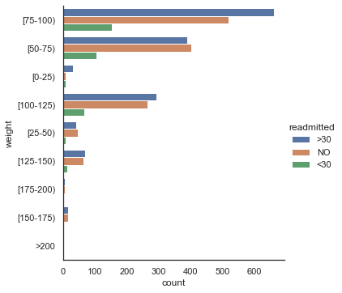

```python
sns.catplot(data = raw_data.loc[raw_data['weight']!="?",['weight','readmitted']],y = 'weight',hue='readmitted',kind='count')
```

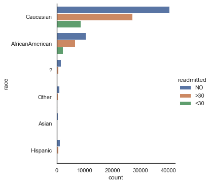

```python
sns.catplot(data = raw_data.loc[raw_data['race']!="-",['race','readmitted']],y = 'race',hue='readmitted',kind='count')
```

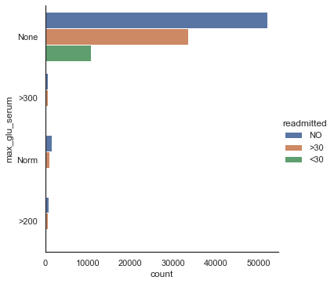

```python
sns.catplot(data = raw_data.loc[raw_data['max_glu_serum']!="-",['max_glu_serum','readmitted']],y = 'max_glu_serum',hue='readmitted',kind='count')
```

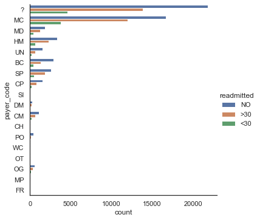

```python
sns.catplot(data = raw_data.loc[raw_data['payer_code']!="-",['payer_code','readmitted']],y = 'payer_code',hue='readmitted',kind='count')
```

```python
raw_data["payer_code"].value_counts()
```

```
?     40256
MC    32439
HM     6274
SP     5007
BC     4655
MD     3532
CP     2533
UN     2448
CM     1937
OG     1033
PO      592
DM      549
CH      146
WC      135
OT       95
MP       79
SI       55
FR        1
Name: payer_code, dtype: int64
```

```python
raw_data["medical_specialty"].nunique()
```

```
73
```

```python
raw_data["readmitted"].value_counts()
```

```
NO     54864
>30    35545
<30    11357
Name: readmitted, dtype: int64
```

```python
raw_data["race"].value_counts()
```

```
Caucasian          76099
AfricanAmerican    19210
?                   2273
Hispanic            2037
Other               1506
Asian                641
Name: race, dtype: int64
```

```python
print(raw_data["readmitted"])
```

```
0          NO
1         >30
2          NO
3          NO
4          NO
         ...
101761    >30
101762     NO
101763     NO
101764     NO
101765     NO
Name: readmitted, Length: 101766, dtype: object
```

```python
raw_data['diag_1'].value_counts().head()
```

```
428    6862
414    6581
786    4016
410    3614
486    3508
Name: diag_1, dtype: int64
```

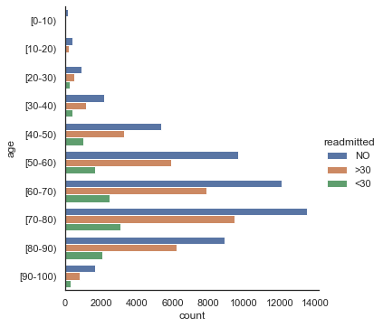

```python
sns.catplot(data = raw_data.loc[raw_data['age']!="?",['age','readmitted']],y = 'age',hue='readmitted',kind='count')
```

### Data Deletion, Imputation and Conversion for & Fitting Logistic Regression Model - Missing Data converted to Individual Levels

```python
# Weight over 90% missing
# encounter_id is unique column not useful for prediction
suggested_delete = ['weight','encounter_id','patient_nbr']
raw_data.drop(suggested_delete,inplace=True, axis=1)
```

```python
# This method is used to transform diag_1, diag_2, diag_3 columns based on conditions below
def transform_diag_column(string: str):
    if "?" in string:
        return "NA"
    elif ("E" in string) or ("V" in string):
        return "ECOISC"
    else:
        value = float(string)
        assert isinstance(value, float), "Conversion of diag column failed, special case present"
        if value >= 250 and value < 251:
            return "DM"
        elif (value >= 390 and value <= 459) or value==785:
            return "DOCS"
        elif (value >= 460 and value <= 519) or value==786:
            return "DORS"
        elif (value >= 520 and value <= 579) or (value in [787,789]):
            return "DODS"
        elif (value >= 800 and value <= 999):
            return "IP"
        elif (value >= 710 and value <= 739):
            return "DOMSACT"
        elif (value >= 580 and value <= 629) or value==788:
            return "DOGNS"
        elif (value >= 140 and value <= 239):
            return "NEO"
        elif (value >= 790 and value <= 799) or (value in [780,781,784]):
            return "OSSIC"
        elif (value >= 790 and value <= 799) or (value in [780,781,784]):
            return "OSSIC"
        elif (value >= 240 and value <= 279) or value==783:
            return "ENMDISWD"
        elif (value >= 680 and value <= 709) or value==782:
            return "DOTSAST"
        elif (value >= 1 and value <= 139):
            return "IPD"
        elif (value >= 290 and value <= 319):
            return "MD"
        elif (value >= 280 and value <= 289):
            return "DOBBO"
        elif (value >= 320 and value <= 359):
            return "DONS"
        elif (value >= 630 and value <= 679):
            return "COPCP"
        elif (value >= 360 and value <= 389):
            return "DOSO"
        elif (value >= 740 and value <= 759):
            return "CA"
        else:
            print("Value: ", value)
```

```python
raw_data['diag_1'] = raw_data['diag_1'].apply(lambda x: transform_diag_column(x))
raw_data['diag_2'] = raw_data['diag_2'].apply(lambda x: transform_diag_column(x))
raw_data['diag_3'] = raw_data['diag_3'].apply(lambda x: transform_diag_column(x))
```

```python
def convert_unknown_to_NA(string: str):
    if string == '?':
        return "NA"
    else:
        return string
```

```python
# Convert missing data in race to category NA: not available
raw_data['race'] = raw_data['race'].apply(lambda x: convert_unknown_to_NA(x))
# Convert payer_code ? to category NA: not available
raw_data['payer_code'] = raw_data['payer_code'].apply(lambda x: convert_unknown_to_NA(x))
```

```python
# Getting top 15 medical_specialty by value_counts()
top_15_medical_specialty = list(pd.DataFrame(raw_data["medical_specialty"].value_counts()).reset_index()[:15]['index'])
```

```python
top_15_medical_specialty = list(pd.DataFrame(raw_data["medical_specialty"].value_counts()).reset_index()[:15]['index'])
def convert_medical_specialty(string: str):
    if string=='?':
        return "NA"
    elif string in top_15_medical_specialty:
        return string
    else:
        return "Others"
raw_data['medical_specialty'] = raw_data['medical_specialty'].apply(lambda x: convert_medical_specialty(x))
```

```python
raw_data['medical_specialty'] = raw_data['medical_specialty'].apply(lambda x: convert_medical_specialty(x))
```

```python
# Get X and y variable
X, y = raw_data.drop(['readmitted'], axis=1),raw_data['readmitted']

# Get categorical columns and numerical columns
categorical_col = X.select_dtypes(include=['object', 'bool']).columns
numeric_col = X.select_dtypes(include=['float','int']).columns
all_col = X.columns
```

```python
params_lr_multi = [
        # Tune One over rest parameters
    {
        "model__C": [10, 15,20,25,30],
        "model__multi_class": ["ovr"],
        "model__solver": ["liblinear"]
    },
    # Tune Multinomial parameters
    {
        "model__C": [10, 15, 20,30],
        "model__multi_class": ["multinomial"],
        "model__solver": ["lbfgs"]
    }
]
cv = StratifiedKFold(n_splits=10, shuffle=True, random_state=1)
def cv_common(df, columns):
    cv_result_summary = df[columns]
    cv_result_summary.index  = np.arange(1,len(cv_result_summary)+1)
    cv_result_summary = cv_result_summary.reset_index()
    return cv_result_summary

def cv_summary(estimator, columns):
    df = pd.DataFrame(estimator.cv_results_)
    cv_result_summary = cv_common(df, columns)
    cv_result_summary = cv_result_summary.rename(columns = {
        "index": "param_combination"
    })
    return cv_result_summary
```

```python
%%time

# Define preprocessing for columns
t_slr = [('cat', OneHotEncoder(handle_unknown='ignore'),categorical_col),
        ('scale',MinMaxScaler(),numeric_col)]
col_transform = ColumnTransformer(t_slr)
model_lr = LogisticRegression(tol=0.0001,C=1.0, class_weight='balanced',random_state=101,max_iter=10000)
pipeline_lr = Pipeline(steps=[('preprocessing',col_transform),
                                     ('model', model_lr)])
# Fit
clf_lr = GridSearchCV(pipeline_lr, params_lr_multi, cv = cv, scoring='roc_auc_ovr_weighted',
                      n_jobs=-2, verbose=15)
search_lr = clf_lr.fit(X, y)
```

```
Fitting 10 folds for each of 9 candidates, totalling 90 fits
CPU times: user 1min 14s, sys: 2.99 s, total: 1min 17s
Wall time: 17min 12s
```

```python
file_name_lr = f"{cwd}/logistic_regression_search_2.sav"
# joblib.dump(search_lr,file_name_lr)
search_lr = joblib.load(file_name_lr)
```

```python
# Get cross validation result
search_columns = ["param_model__C",'param_model__multi_class','param_model__solver',
                                "mean_test_score","mean_fit_time","rank_test_score"]
df_search_result = cv_summary(search_lr,search_columns)
df_search_result
```

|  | param_combination | param_model__C | param_model__multi_class | param_model__solver | mean_test_score | mean_fit_time | rank_test_score |
| --- | --- | --- | --- | --- | --- | --- | --- |
| 0 | 1 | 10 | ovr | liblinear | 0.675217 | 129.579676 | 5 |
| 1 | 2 | 15 | ovr | liblinear | 0.675267 | 135.753840 | 4 |
| 2 | 3 | 20 | ovr | liblinear | 0.675285 | 145.241070 | 3 |
| 3 | 4 | 25 | ovr | liblinear | 0.675302 | 149.289326 | 2 |
| 4 | 5 | 30 | ovr | liblinear | 0.675315 | 152.201373 | 1 |
| 5 | 6 | 10 | multinomial | lbfgs | 0.670687 | 170.560082 | 9 |
| 6 | 7 | 15 | multinomial | lbfgs | 0.670724 | 183.531837 | 8 |
| 7 | 8 | 20 | multinomial | lbfgs | 0.670737 | 187.360534 | 7 |
| 8 | 9 | 30 | multinomial | lbfgs | 0.670751 | 175.321616 | 6 |

```python
def get_acc_score(model, x, y):
    return model.score(x, y)

x_axis_labels = ["Readmitted <30", "Readmitted >30", "Not Readmitted"] # labels for x-axis
y_axis_labels = ["Readmitted <30", "Readmitted >30", "Not Readmitted"] # labels for y-axis

def get_classification_report_multi_response(x_train, y_train, x_test, y_test, pred, model):
    """
    This function is used to get comprehensive classification report for multiple response:
    Training Accuracy, Test Accuracy, print classification_report, plot confusion matrix.
    """
    print(f"Weighted AUC: {get_acc_score(model, x_train, y_train):,.5f}")
    print("Classification Report:")
    print(classification_report(y_test,pred))
    cm_n = confusion_matrix(y_test,pred)
    ax = sns.heatmap(cm_n,cmap='Blues',annot=True,fmt='2d',xticklabels=x_axis_labels, yticklabels=y_axis_labels)
    ax.set(xlabel='Predicted Label', ylabel='True Label')
    ax.set_title("Confusion Matrix",fontdict={'fontsize':20},pad=15)
```

```
Weighted AUC: 0.67998
Classification Report:
              precision    recall  f1-score   support

         <30       0.27      0.19      0.22     11357
         >30       0.49      0.42      0.45     35545
          NO       0.64      0.74      0.69     54864

    accuracy                           0.57    101766
   macro avg       0.47      0.45      0.46    101766
weighted avg       0.55      0.57      0.56    101766
```

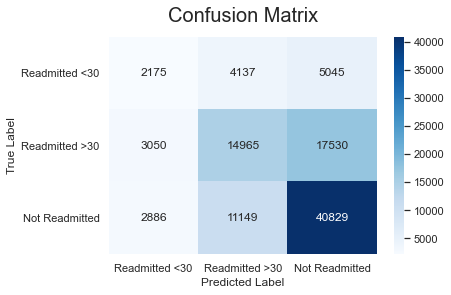

```python
y_hat_lg = search_lr.predict(X)
get_classification_report_multi_response(X, y, X, y, y_hat_lg, search_lr)
```

```python
onehot_columns= search_lr.best_estimator_.named_steps['preprocessing'].named_transformers_['cat'].get_feature_names(input_features=categorical_col)
features_list = list(onehot_columns)
features_list.extend(list(numeric_col))
```

```python
less_30 = search_lr.best_estimator_._final_estimator.coef_[0]
greater_30 = search_lr.best_estimator_._final_estimator.coef_[1]
no_admission = search_lr.best_estimator_._final_estimator.coef_[2]
```

```python
less_30 = pd.DataFrame(zip(features_list, less_30), columns =('feature name','coefficient'))
greater_30 = pd.DataFrame(zip(features_list, greater_30), columns =('feature name','coefficient'))
no_admission = pd.DataFrame(zip(features_list, no_admission), columns =('feature name','coefficient'))
```

```python
less_30.sort_values(by='coefficient', key=abs,ascending=False)[:10]
```

|  | feature name | coefficient |
| --- | --- | --- |
| 29 | discharge_disposition_id_11 | -7.290246 |
| 252 | number_inpatient | 5.616444 |
| 251 | number_emergency | 4.753703 |
| 25 | admission_type_id_7 | -3.694891 |
| 30 | discharge_disposition_id_12 | 3.386354 |
| 35 | discharge_disposition_id_17 | -3.169061 |
| 34 | discharge_disposition_id_16 | -2.901195 |
| 28 | discharge_disposition_id_10 | -2.734104 |
| 54 | admission_source_id_10 | -2.729364 |
| 37 | discharge_disposition_id_19 | -2.676893 |

```python
greater_30.sort_values(by='coefficient', key=abs,ascending=False)[:10]
```

|  | feature name | coefficient |
| --- | --- | --- |
| 29 | discharge_disposition_id_11 | -7.292866 |
| 251 | number_emergency | 5.893515 |
| 250 | number_outpatient | 3.306798 |
| 25 | admission_type_id_7 | -3.189072 |
| 252 | number_inpatient | 2.942271 |
| 32 | discharge_disposition_id_14 | -2.502248 |
| 37 | discharge_disposition_id_19 | -2.228082 |
| 34 | discharge_disposition_id_16 | 1.838597 |
| 28 | discharge_disposition_id_10 | 1.815514 |
| 230 | glyburide-metformin_Down | -1.814557 |

```python
no_admission.sort_values(by='coefficient', key=abs,ascending=False)[:10]
```

|  | feature name | coefficient |
| --- | --- | --- |
| 251 | number_emergency | -16.773356 |
| 29 | discharge_disposition_id_11 | 8.489421 |
| 252 | number_inpatient | -8.005087 |
| 25 | admission_type_id_7 | 3.873536 |
| 250 | number_outpatient | -3.543765 |
| 37 | discharge_disposition_id_19 | 3.327759 |
| 39 | discharge_disposition_id_20 | 2.262298 |
| 215 | miglitol_Down | -2.069000 |
| 62 | admission_source_id_25 | 1.961177 |
| 32 | discharge_disposition_id_14 | 1.916457 |

### Data Deletion, Imputation and Conversion for & Fitting Logistic Regression Model - Imputation using SimpleImputer

```python
path_file = f"{d}/casestudy2/dataset_diabetes/diabetic_data.csv"
data = pd.read_csv(path_file)
# Convert columns to correct type
data["encounter_id"] = data["encounter_id"].astype(str)
data["patient_nbr"] = data["patient_nbr"].astype(str)
data["admission_type_id"] = data["admission_type_id"].astype(str)
data["discharge_disposition_id"] = data["discharge_disposition_id"].astype(str)
data["admission_source_id"] = data["admission_source_id"].astype(str)
```

```python
# Identify attributes missing over 15% of values
columns_missing_rate = 100*((data=="?").sum(axis = 0) / len(data))
columns_missing_rate = pd.DataFrame(columns_missing_rate)
columns_missing_rate = columns_missing_rate.reset_index()
columns_missing_rate.columns = ['name','rate']
print("     Initial Missing Data Inspection with all Attributes In     \n")
print('{:45s} {:4s}%'.format("Variable Name:","Missing Percentage"))
print("________________________________________________________________")
for index, row in columns_missing_rate.iterrows():
    if row['rate'] > 0:
        print(' {:45s} {:4s}%'.format(row['name'],str(np.round(row['rate'],4))))
```

```
     Initial Missing Data Inspection with all Attributes In

Variable Name:                                Missing Percentage%
________________________________________________________________
 race                                          2.2336%
 weight                                        96.8585%
 payer_code                                    39.5574%
 medical_specialty                             49.0822%
 diag_1                                        0.0206%
 diag_2                                        0.3518%
 diag_3                                        1.3983%
```

```python
# Convert ? to np.nan, and classify diag cols
def new_transform_diag_column(string: str):
    if "?" in string:
        return np.nan
    elif ("E" in string) or ("V" in string):
        return "ECOISC"
    else:
        value = float(string)
        assert isinstance(value, float), "Conversion of diag column failed, special case present"
        if value >= 250 and value < 251:
            return "DM"
        elif (value >= 390 and value <= 459) or value==785:
            return "DOCS"
        elif (value >= 460 and value <= 519) or value==786:
            return "DORS"
        elif (value >= 520 and value <= 579) or (value in [787,789]):
            return "DODS"
        elif (value >= 800 and value <= 999):
            return "IP"
        elif (value >= 710 and value <= 739):
            return "DOMSACT"
        elif (value >= 580 and value <= 629) or value==788:
            return "DOGNS"
        elif (value >= 140 and value <= 239):
            return "NEO"
        elif (value >= 790 and value <= 799) or (value in [780,781,784]):
            return "OSSIC"
        elif (value >= 790 and value <= 799) or (value in [780,781,784]):
            return "OSSIC"
        elif (value >= 240 and value <= 279) or value==783:
            return "ENMDISWD"
        elif (value >= 680 and value <= 709) or value==782:
            return "DOTSAST"
        elif (value >= 1 and value <= 139):
            return "IPD"
        elif (value >= 290 and value <= 319):
            return "MD"
        elif (value >= 280 and value <= 289):
            return "DOBBO"
        elif (value >= 320 and value <= 359):
            return "DONS"
        elif (value >= 630 and value <= 679):
            return "COPCP"
        elif (value >= 360 and value <= 389):
            return "DOSO"
        elif (value >= 740 and value <= 759):
            return "CA"
        else:
            print("Value: ", value)




def new_convert_unknown_to_NA(string: str):
    if string == '?':
        return np.nan
    else:
        return string
```

```python
data['diag_1'] = data['diag_1'].apply(lambda x: new_transform_diag_column(x))
data['diag_2'] = data['diag_2'].apply(lambda x: new_transform_diag_column(x))
data['diag_3'] = data['diag_3'].apply(lambda x: new_transform_diag_column(x))

data['race'] = data['race'].apply(lambda x: new_convert_unknown_to_NA(x))
data['weight'] = data['weight'].apply(lambda x: new_convert_unknown_to_NA(x))
data['payer_code'] = data['payer_code'].apply(lambda x: new_convert_unknown_to_NA(x))


top_15_medical_specialty_data = list(pd.DataFrame(data["medical_specialty"].value_counts()).reset_index()[:15]['index'])

def new_convert_medical_specialty(string: str):
    if string=='?':
        return np.nan
    elif string in top_15_medical_specialty_data:
        return string
    else:
        return "Others"


data['medical_specialty'] = data['medical_specialty'].apply(lambda x: new_convert_medical_specialty(x))
```

```python
# delete values

suggested_delete = ['weight','encounter_id','patient_nbr']
data.drop(suggested_delete,inplace=True, axis=1)
```

#### Method 2 of imputation

```python
from sklearn.impute import SimpleImputer
```

```python
X, y = data.drop(['readmitted'], axis=1),data['readmitted']
# Get categorical columns and numerical columns
categorical_col = X.select_dtypes(include=['object', 'bool']).columns
numeric_col = X.select_dtypes(include=['float','int']).columns
all_col = X.columns
```

```python
X.shape
```

```
(101766, 46)
```

```python
%%time



params_lr_multi_method_2 = [
    # Tune One over rest parameters
    {
        "model__C": [10, 15,20,25,30],
        "model__multi_class": ["ovr"],
        "model__solver": ["liblinear"]
    },
    # Tune Multinomial parameters
    {
        "model__C": [ 15, 20],
        "model__multi_class": ["multinomial"],
        "model__solver": ["lbfgs"]
    }
]


# Define preprocessing for columns


categorical_pipe_method_2 = Pipeline(steps=[("cat_impute", SimpleImputer(missing_values=np.nan, strategy='most_frequent')),
                                     ('cat', OneHotEncoder(handle_unknown='ignore'))])
numeric_pipe_method_2 = Pipeline(steps=[('numeric_impute', SimpleImputer(missing_values=np.nan, strategy='mean')),
                                     ('scale',MinMaxScaler())])


t_slr_impute_method_2 = [
    ('cat', categorical_pipe_method_2, categorical_col),

    ('scale', numeric_pipe_method_2, numeric_col)]


col_transform_impute_method_2 = ColumnTransformer(t_slr_impute_method_2)
model_lr_method_2 = LogisticRegression(tol=0.0001,C=1.0, class_weight='balanced',random_state=101,max_iter=10000)

pipeline_lr_impute_method_2 = Pipeline(steps=[('preprocessing',col_transform_impute_method_2),
                                     ('model', model_lr_method_2)])





# Fit
clf_lr_impute_method_2 = GridSearchCV(pipeline_lr_impute_method_2, params_lr_multi_method_2, cv = cv, scoring='roc_auc_ovr_weighted',
                      n_jobs=-2, verbose=15, return_train_score=True)

search_lr_impute_method_2 = clf_lr_impute_method_2.fit(X, y)
```

```
Fitting 10 folds for each of 7 candidates, totalling 70 fits
CPU times: user 1min 8s, sys: 2.96 s, total: 1min 11s
Wall time: 13min 25s
```

```python
file_name_lr_method_2 = f"{cwd}/method_2_logistic_regression_search.sav"
#joblib.dump(search_lr_impute_method_2,file_name_lr_method_2)
search_lr_impute_method_2 = joblib.load(file_name_lr_method_2)
```

```python
# Get cross validation result
search_columns = ["param_model__C",'param_model__multi_class','param_model__solver',
                                "mean_test_score","mean_fit_time","rank_test_score"]
df_search_result_method_2 = cv_summary(search_lr_impute_method_2,search_columns)
df_search_result_method_2
```

[output not shown]

```
Weighted AUC: 0.67372
Classification Report:
              precision    recall  f1-score   support

         <30       0.26      0.18      0.22     11357
         >30       0.51      0.31      0.39     35545
          NO       0.62      0.81      0.70     54864

    accuracy                           0.57    101766
   macro avg       0.47      0.44      0.44    101766
weighted avg       0.54      0.57      0.54    101766
```

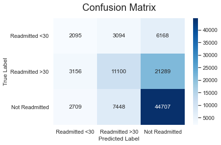

```python
y_hat_lg_method_2 = search_lr_impute_method_2.predict(X)
get_classification_report_multi_response(X, y, X, y, y_hat_lg_method_2, search_lr_impute_method_2)
```

```python
onehot_columns_impute= search_lr_impute_method_2.best_estimator_.named_steps['preprocessing'].named_transformers_['cat'].named_steps['cat'].get_feature_names(input_features=categorical_col)
features_list_impute = list(onehot_columns_impute)
features_list_impute.extend(list(numeric_col))

less_30_impute = search_lr_impute_method_2.best_estimator_._final_estimator.coef_[0]
greater_30_impute = search_lr_impute_method_2.best_estimator_._final_estimator.coef_[1]
no_admission_impute = search_lr_impute_method_2.best_estimator_._final_estimator.coef_[2]

less_30_impute = pd.DataFrame(zip(features_list_impute, less_30_impute), columns =('feature name','coefficient'))
greater_30_impute = pd.DataFrame(zip(features_list_impute, greater_30_impute), columns =('feature name','coefficient'))
no_admission_impute = pd.DataFrame(zip(features_list_impute, no_admission_impute), columns =('feature name','coefficient'))
```

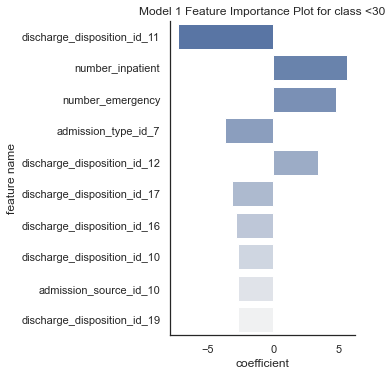

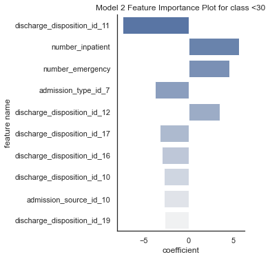

```python
sns.set_style("white")

sns.catplot(x="coefficient",
            y="feature name",
            kind="bar",
            palette = "light:b_r",
            data=less_30.sort_values(by='coefficient', key=abs,ascending=False)[:10]).set(title="Model 1 Feature Importance Plot for class <30")

sns.catplot(x="coefficient",
            y="feature name",
            kind="bar",
            palette = "light:b_r",
            data=less_30_impute.sort_values(by='coefficient', key=abs,ascending=False)[:10]).set(title="Model 2 Feature Importance Plot for class <30")

None
```